# Data Preprocessing

The data preparation before analysis is based on the following tutorial: https://nbisweden.github.io/workshop-scRNAseq/labs/compiled/scanpy/scanpy_01_qc.html and was included here to ensure the reproducability of the analysis.

**Loading the necessary libraries**

```python
import scanpy as sc
import pandas as pd
import numpy as np
```

```python
# settings can be adapted individually
sc.settings.verbosity = 3
sc.logging.print_header()
sc.settings.set_figure_params(dpi = 100, format = 'png')
```

```
scanpy==1.7.2 anndata==0.7.6 umap==0.4.6 numpy==1.20.1 scipy==1.6.2 pandas==1.2.4 scikit-learn==0.24.2 statsmodels==0.12.2 python-igraph==0.9.1 louvain==0.7.0
```

**Load the scRNA-seq data**

Data was taken form the following publication of Cano-Gamez et al.: https://www.nature.com/articles/s41467-020-15543-y

```python
canogamez = sc.read_h5ad("/corgi/scdata/henriksson/canogamez/cleaned.h5ad") # change to your data path
canogamez.var_names_make_unique()
```

```python
# create a path to store the preprocessed file
results_file = '/canogamez_preprocessing.h5ad' # change to your data path
```

First, the `iTreg` sample derived from `Donor2` was removed due to an unusually high dropout rate as described by Cano-Gamez et al. :

```python
canogamez_D2 = canogamez[(canogamez.obs['donor.id']=='D2')&(canogamez.obs['cytokine.condition']=='iTreg')]
remove = canogamez_D2.obs.index.to_list()
index = canogamez.obs.index.to_list()
keep = list(set(index)-set(remove))
```

```python
canogamez = canogamez[keep,: ]
```

## Quality Control (QC)

Identify genes belonging to a specific group

```python
 # mitochondrial genes
canogamez.var['mt'] = canogamez.var_names.str.startswith('MT-')
# ribosomal genes
canogamez.var['ribo'] = canogamez.var_names.str.startswith(("RPS","RPL"))
# hemoglobin genes.
canogamez.var['hb'] = canogamez.var_names.str.contains(("^HB[^(P)]"))
```

```
Trying to set attribute `.var` of view, copying.
```

Calculate Quality of the data

calculation of:

- per cell (`.obs`):
  - n_genes_by_counts
  - total_counts
  - mitochondrial genes: total_counts_mt, pct_counts_mt
- per gen(`.var`):`
  - n_cells_by_counts
  - mean_counts,total_counts
  - pct_dropout_by_counts = percentage of cells with counts of zero for each gene

```python
sc.pp.calculate_qc_metrics(canogamez, qc_vars=['mt','ribo','hb'], percent_top=None, log1p=False, inplace=True)
```

Plot QC

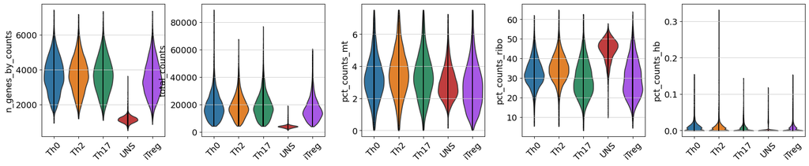

```python
sc.pl.violin(canogamez, ['n_genes_by_counts', 'total_counts', 'pct_counts_mt','pct_counts_ribo', 'pct_counts_hb'],
             jitter=False, groupby = 'cytokine.condition', rotation= 45, wspace=1)
```

- UNS cells have less cell counts and thus less gene counts
- UNS have more ribsomal genes in proportion to other genes

## Filtering

Set thresholds:

```python
sc.pp.filter_cells(canogamez, min_genes=200)
sc.pp.filter_genes(canogamez, min_cells=3)
```

```
filtered out 420 genes that are detected in less than 3 cells
```

Highest expressed genes:

```
normalizing counts per cell
    finished (0:00:00)
```

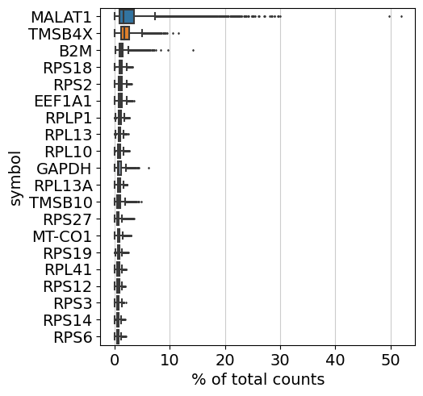

```python
sc.pl.highest_expr_genes(canogamez, n_top=20)
```

MALAT1: act as a transcriptional regulator for numerous genes -> highly expressed in almost every cell and therefore removed from the analysis lateron

Mito/Ribo filtering:

```python
canogamez = canogamez[canogamez.obs.pct_counts_mt < 7.5, :]
canogamez = canogamez[canogamez.obs.pct_counts_ribo > 5, :]
```

Filter for UMI content:

```python
canogamez = canogamez[canogamez.obs.n_genes_by_counts > 500, :]
```

Remove mt and hb genes as well as MALAT1

```python
# calculate new as low expressed genes were removed
mito_genes = canogamez.var_names.str.startswith('MT-')
hb_genes = canogamez.var_names.str.contains('^HB[^(P)]')

malat1 = canogamez.var_names.str.startswith('MALAT1')

remove = np.add(mito_genes, malat1)
remove = np.add(remove, hb_genes)
keep = np.invert(remove)

canogamez = canogamez[:,keep]
```

## Chromosomal Information and Sample Sex

*Note: Not necessary here as only male donors were used. Only for consistency.*

Create annotation

```python
annot = sc.queries.biomart_annotations(
        "hsapiens",
        ["ensembl_gene_id", "external_gene_name", "start_position",
         "end_position", "chromosome_name"],).set_index("external_gene_name")
```

Identify chromosome y and x genes

```python
chrY_genes = canogamez.var_names.intersection(annot.index[annot.chromosome_name == "Y"])
chrX_genes = canogamez.var_names.intersection(annot.index[annot.chromosome_name == "XIST"])
```

*Here: no XIST genes present*

## Cell Cycle Scores

- score list: difference of mean expression of the given list and the mean expression of reference genes
- reference genes: function randomly chooses a bunch of genes matching the distribution of the expression of the given list
- adds three more variables to data:
  - score for S phase
  - a score for G2M phase
  - predicted cell cycle phase

Normalize data before running

```python
# normalize to depth 10 000
# Note: Check for mean count depth before by `.obs.describe()`
sc.pp.normalize_per_cell(canogamez, counts_per_cell_after=1e4)

# save normalized counts as raw data
canogamez.raw = canogamez

# logaritmize
sc.pp.log1p(canogamez)
```

```
normalizing by total count per cell
Trying to set attribute `.obs` of view, copying.
    finished (0:00:02): normalized adata.X and added    'n_counts', counts per cell before normalization (adata.obs)
```

Load all cell cycle genes  
downloaded here: https://github.com/theislab/scanpy_usage/blob/master/180209_cell_cycle/data/regev_lab_cell_cycle_genes.txt

```python
cell_cycle_genes = [x.strip() for x in open('/home/plutowski/notebooks/Markers/regev_lab_cell_cycle_genes.txt')]
```

```python
# Split into 2 lists
s_genes = cell_cycle_genes[:43]
g2m_genes = cell_cycle_genes[43:]
```

```python
# check how many genes are present in the data
cell_cycle_genes = [x for x in cell_cycle_genes if x in canogamez.var_names]
print(len(cell_cycle_genes))
```

```
96
```

Calculate and plot score

```python
sc.tl.score_genes_cell_cycle(canogamez, s_genes=s_genes, g2m_genes=g2m_genes)
```

```
calculating cell cycle phase
computing score 'S_score'
WARNING: genes are not in var_names and ignored: ['MLF1IP']
    finished: added
    'S_score', score of gene set (adata.obs).
    385 total control genes are used. (0:00:01)
computing score 'G2M_score'
    finished: added
    'G2M_score', score of gene set (adata.obs).
    469 total control genes are used. (0:00:01)
-->     'phase', cell cycle phase (adata.obs)
```

```
... storing 'phase' as categorical
WARNING: saving figure to file figures/violincell_cycle_cytokines.png
```

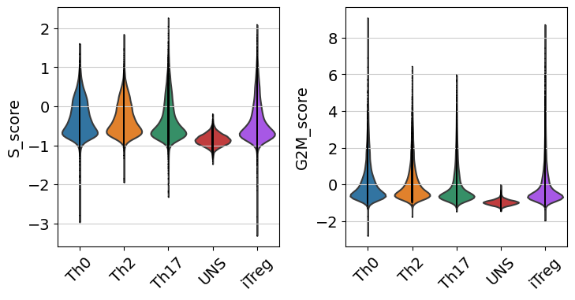

```python
sc.pl.violin(canogamez, ['S_score', 'G2M_score'],
             jitter=False, groupby = 'cytokine.condition', rotation=45, save='cell_cycle_cytokines')
```

## Doublet Prediction

Import needed library

```python
import scrublet as scr
```

Run prediction

```
Preprocessing...
Simulating doublets...
Embedding transcriptomes using PCA...
Calculating doublet scores...
Automatically set threshold at doublet score = 0.63
Detected doublet rate = 0.1%
Estimated detectable doublet fraction = 32.5%
Overall doublet rate:
	Expected   = 10.0%
	Estimated  = 0.3%
Elapsed time: 71.4 seconds
```

```
39
```

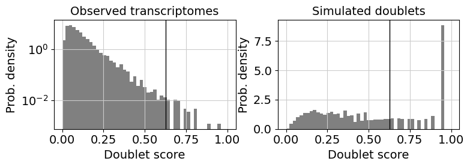

```python
scrub = scr.Scrublet(canogamez.raw.X)
canogamez.obs['doublet_scores'], canogamez.obs['predicted_doublets'] = scrub.scrub_doublets()
scrub.plot_histogram()

sum(canogamez.obs['predicted_doublets'])
```

```python
# add in column with doublet info
canogamez.obs['doublet_info'] = canogamez.obs["predicted_doublets"].astype(str)
```

```
... storing 'doublet_info' as categorical
```

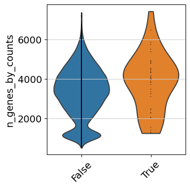

```python
sc.pl.violin(canogamez, 'n_genes_by_counts',
             jitter=False, groupby = 'doublet_info', rotation=45)
```

*Optional: Doublets can be removed*

```python
# canogamez = canogamez.raw.to_canogamez()
# canogamez = canogamez[canogamez.obs['doublet_info'] == 'False',:]
```

## Highly variable genes

```
extracting highly variable genes
    finished (0:00:02)
--> added
    'highly_variable', boolean vector (adata.var)
    'means', float vector (adata.var)
    'dispersions', float vector (adata.var)
    'dispersions_norm', float vector (adata.var)
```

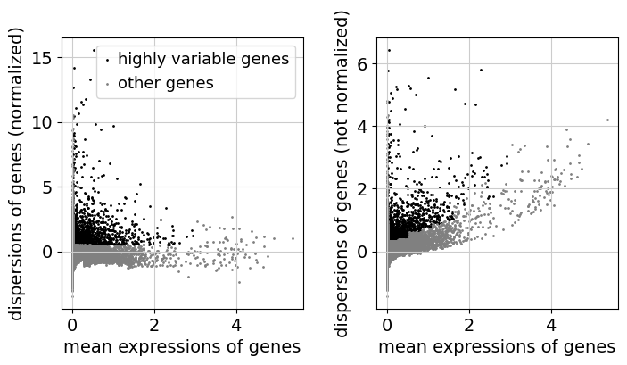

```python
sc.pp.highly_variable_genes(canogamez, min_mean=0.0125, max_mean=3, min_disp=0.5)
sc.pl.highly_variable_genes(canogamez)
```

Take only highly variable genes for the further analysis

```python
canogamez = canogamez[:, canogamez.var.highly_variable]
```

### Further preprocessing

Regress out the effects of number of counts, mt genes, cell cycle and batch.10x

```python
sc.pp.regress_out(canogamez, ['total_counts', 'pct_counts_mt','batch.10X', 'S_score', 'G2M_score'])
```

```
regressing out ['total_counts', 'pct_counts_mt', 'batch.10X', 'S_score', 'G2M_score']
    sparse input is densified and may lead to high memory use
    finished (0:00:53)
```

Scale for unique variance

```python
sc.pp.scale(canogamez, max_value=10)
```

### Store the preprocessed data

```python
canogamez.write(results_file)
```